# Supervised Learning and Visualisation

Assignment 1

Abdool Al-Khaledi, Amalia Tsakali, Li-Yeun Xu, Willem van Veluw

2022-09-19

## Introduction

For the purpose of this assignment, exploratory data analysis will be performed on the data set “Spotify top chart songs 2022”, which was obtained from Kaggle and uploaded by user “SVETA151”. The dataset is a collection of top charting songs in 2022 according to the weekly Spotify Top 200 Global chart. Each of the songs listed in the dataset has charted in the top 200 according to Spotify for a minimum of one week. That being said, the dataset contains 646 rows along with 17 columns. Each row lists a unique song while each column outlines a different feature of the song. These features include necessary identifying information such as artist(s) and song name. Moreover, these features include numerical measures such as weeks on chart, loudness, tempo and duration. Along with categorical measures such as the key of the song, the time signature and modality (major/minor). For this assignment, various factettes of the dataset will be analyzed. Focus will be placed on comparing features to determine if any correlate with each other. Furthermore, we will also investigate whether any feature correlates with the number of weeks charted, or the peak rank.

## Libraries & Packages

```r
list.of.packages <- c("ggpubr")
new.packages <- list.of.packages[!(list.of.packages %in% installed.packages()[,"Package"])]
if(length(new.packages))
  install.packages(new.packages)

library(ggpubr)
library(tidyverse)
```

## Load the data

In this section we load and pre-process the data. This means that we define which variables are factors and change their labels. We will also add some variables in order to make pretty plots.\

```r
data <-
  read_csv("data/spotify_top_charts_22.csv") %>%
  select(-uri) %>%
  mutate(key = recode(key,
                      "0"="C","1"="C#","2"="D","3"="D#","4"="E","5"="F","6"="F#","7"="G","8"="G#","9"="A",
                      "10"="A#","11"="B")
                      %>% as.factor()) %>%
  mutate(mode = recode(mode,
                      "0" = "minor", "1" = "major")
                      %>% as.factor()) %>%
  mutate(time_signature = recode(time_signature,
                      "1" = "1/4", "3" = "3/4", "4" = "4/4", "5" = "5/4")
                      %>% as.factor()) %>%
  mutate(colab = case_when(grepl(",", artist_names) ~ "YES", !grepl(",", artist_names) ~ "NO") %>% as.factor())
```

## Inspect the data

```r
View(data)
```

## Create Table

| Variable | Mean | Std | Min | Q1 | Median | Q3 | Max |
| --- | --- | --- | --- | --- | --- | --- | --- |
| Peak rank | 65.92 | 57.0045 | 1.0000 | 15.0000 | 51.5000 | 108.7500 | 200.0000 |
| Weeks on chart | 19.50 | 37.8139 | 1.0000 | 1.0000 | 5.0000 | 19.7500 | 269.0000 |
| Danceability | 0.6744 | 0.1515 | 0.1930 | 0.5690 | 0.6744 | 0.7907 | 0.9850 |
| Energy | 0.6408 | 0.1655 | 0.0218 | 0.5325 | 0.6520 | 0.7690 | 0.9720 |
| Loudness | -6.3560 | 2.6275 | -31.1600 | -7.7160 | -6.3560 | -4.5960 | -0.5140 |
| Speechiness | 0.1098 | 0.1022 | 0.0232 | 0.0413 | 0.0635 | 0.1358 | 0.6110 |
| Acousticness | 0.2557 | 0.2626 | 1.68e-05 | 0.0404 | 0.1555 | 0.4245 | 0.9690 |
| Instrumentalness | 0.0137 | 0.0778 | 0.0000 | 0.0000 | 1.5e-06 | 1.e-4 | 0.9080 |
| Liveness | 0.1765 | 0.1338 | 0.0264 | 0.0931 | 0.1200 | 0.2318 | 0.9680 |
| Tempo | 121.0916 | 28.2680 | 66.1650 | 98.4300 | 119.9700 | 139.9700 | 205.8600 |
| Duration (ms) | 203630 | 54967 | 36935 | 169902 | 196389 | 229214 | 613027 |

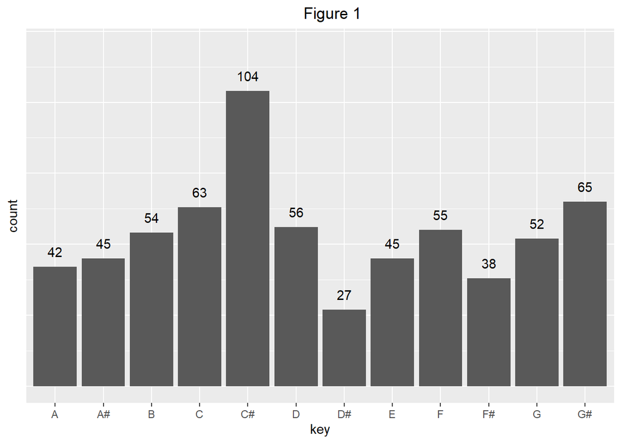

The variable *mode* only has two possible values: either *minor* or *major*. We have 373 songs written in major and 273 songs in minor.

In the barplot below we see the frequencies of the variable *time signature*. The majority of the songs are written in a time signature of 4/4.

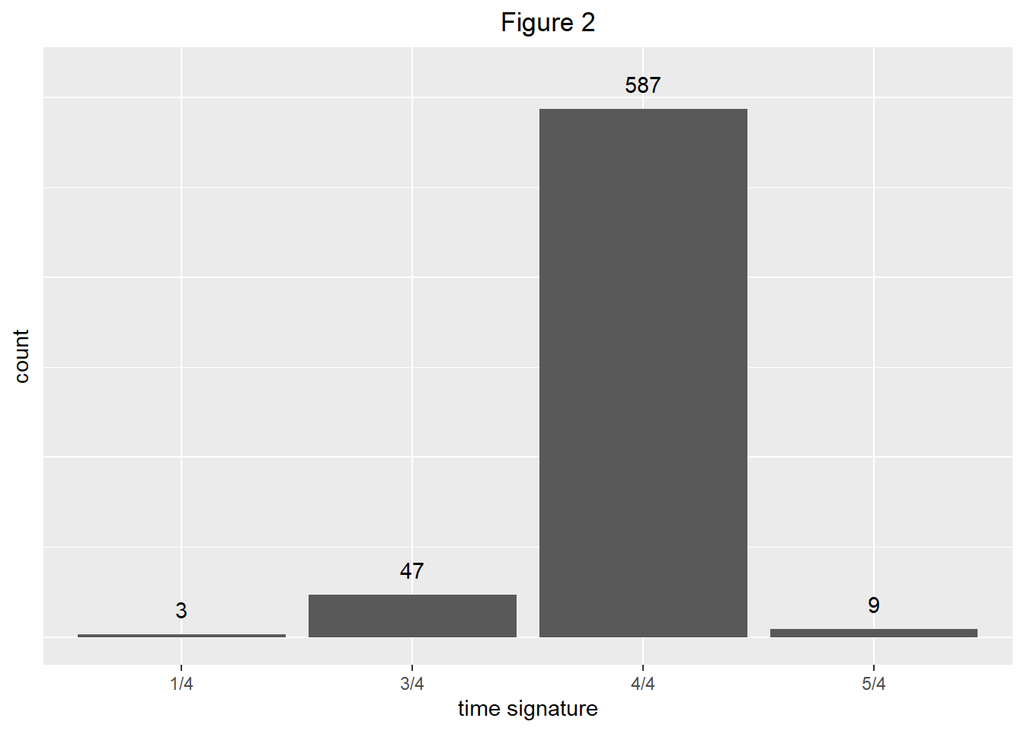

During the exploration of the dataset, we noticed that many of the top songs are colaborations of artists. However, the majority of songs are written by one artist compared to colaborations of artists: 417 and 229 respectively.

## Nice plot

When considering the first two variables of the dataset, peak rank and weeks on chart, one might expect that songs with a high peak rank will last more weeks on chart. For a song at rank 1, it may take more weeks to drop out the top 200 due to the high popularity of the song. To explore this thought, we made the plot investigating weeks on chart vs peak rank. From the plot we see our thought confirmed, or at least up to some peak rank. For the really popular songs, songs with a rank between 1 and 50, it is clear that they stay on the chart for weeks than less popular songs do. We test this by performing a Pearsons correlation test. The test returned a correlation estimate of -0.3525126. This demonstrates a negative correlation since a higher peak rank is represented by a low numerical estimate. Furthermore, a “For loop” was written to test every numerical feature against another. This returned energy/loudness correlation of 0.69 p<2.2e-16 and an Energy/acousticness correlation of -0.59 p<2.2e-16.

```
##
##  Pearson's product-moment correlation
##
## data:  data$peak_rank and data$weeks_on_chart
## t = -9.5594, df = 644, p-value < 2.2e-16
## alternative hypothesis: true correlation is not equal to 0
## 95 percent confidence interval:
##  -0.4182783 -0.2830702
## sample estimates:
##        cor
## -0.3525126
```

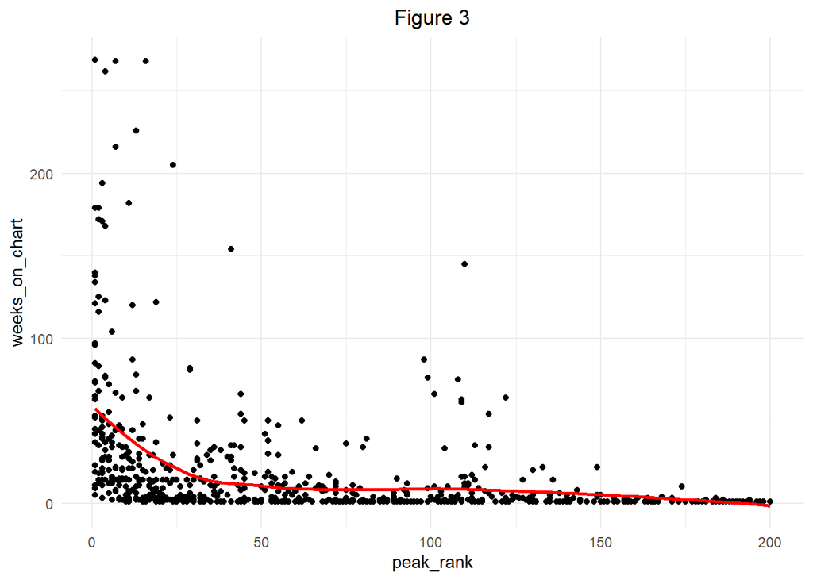

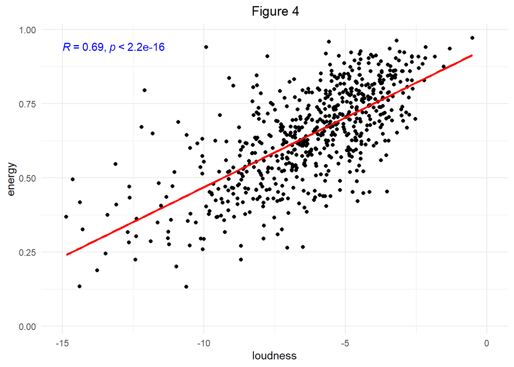

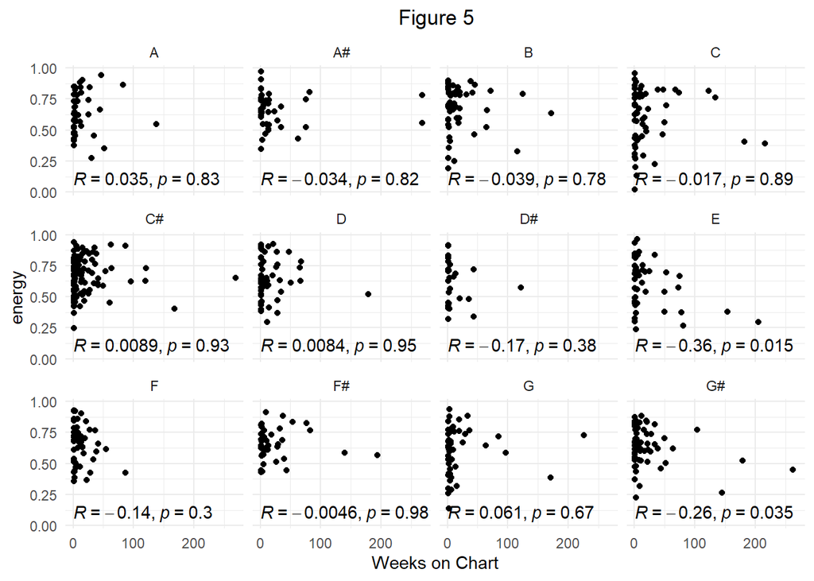

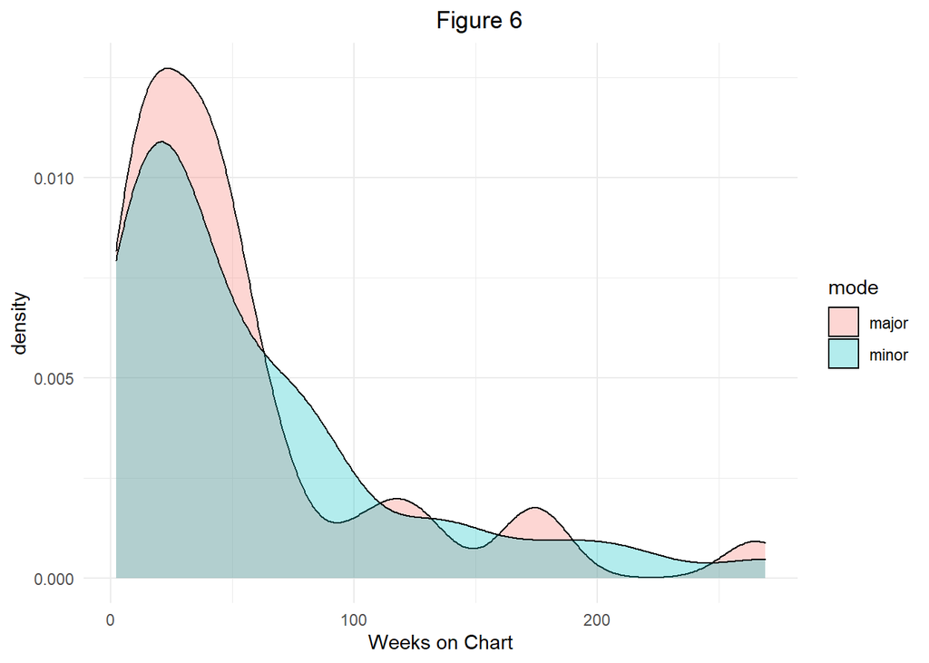

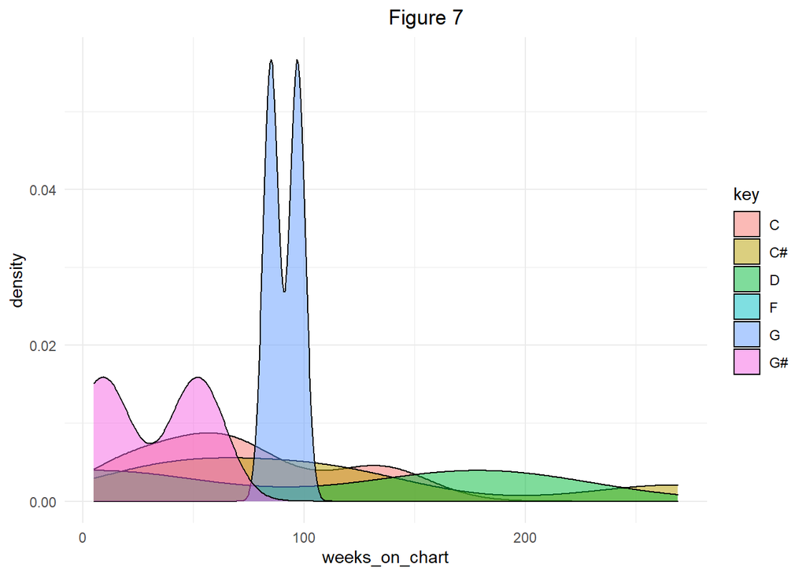

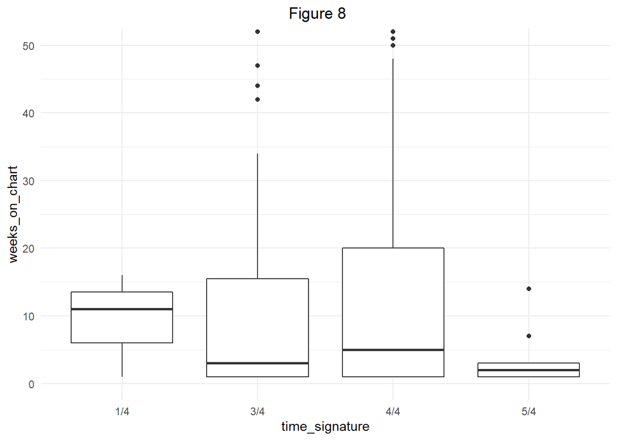

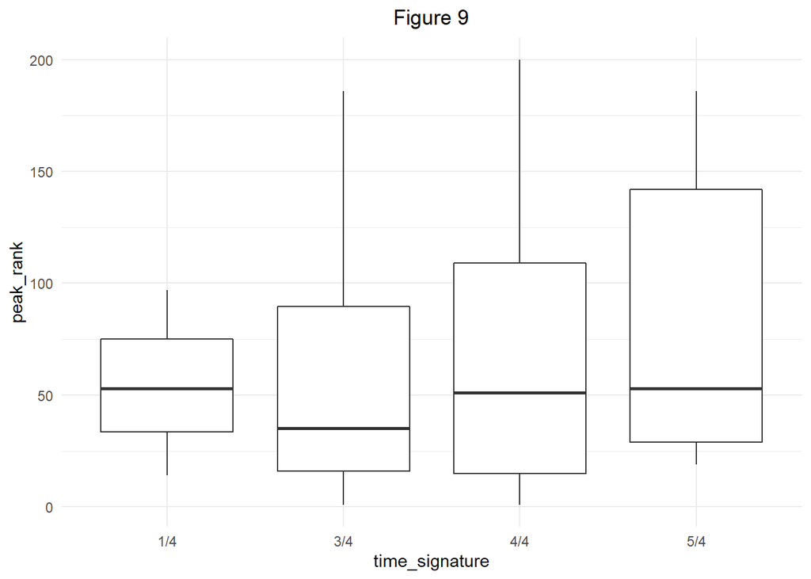

# Explain what you did and why (maximum 5 paragraphs total) if applicable, note findings such as missingness, outliers or unlikely values or group differences, etcetera.

## 1. Cleaning the data

To clean the data, we have

- Deleted “uri”
- Recoded the variables key, mode and time signature
- Defined the variables key, mode and time signature as being factors
- Added a variable colab. This tells whether or not the song is a collaboration of artists